# 1. ddp week 4 pitch presentation (Earthquakes)

Brian GeuR  
18 Sept 2017

### 2. First Slide

Between hurricanes, wildfires, and earthquakes, there are a LOT of natural disasters going on right now.

This app allows you to explore one of those categories: earthquakes. It visualizes 30 days of global seismic activity, up to the last five minutes.

You can try it out at https://bmg123.shinyapps.io/30days/

### 3. Credits

This app is heavily indebted to two sources:

- The US Geological Survey's datafeed of seismic activity, available at https://earthquake.usgs.gov/
- RStudio's excellent Shiny docs, which have a sample app for exploring seismic activity in Fiji (using a different dataset). https://rstudio.github.io/leaflet/shiny.html

### 4. App UI Outline

We first get the data from the USGS.

```r
earthquakes <- read.delim("https://earthquake.usgs.gov/earthquakes/feed/v1.0/summary/1.0_month.csv", sep=",")
```

Next, build the UI in Shiny. Controls are added to filter magnitude, assign a color scheme, and show/hide the legend.

```r
library(shiny)
library(leaflet)
library(RColorBrewer)
# Build a UI in Shiny
ui <- bootstrapPage(
  tags$style(type = "text/css", "html, body {width:100%;height:100%}"),
  leafletOutput("map", width = "100%", height = "100%"),
  absolutePanel(top = 10, right = 10,
                sliderInput("range", "Magnitudes", min(earthquakes$mag), max(earthquakes$mag),
                            value = range(earthquakes$mag), step = 0.1
                ),
                selectInput("colors", "Color Scheme",
                            rownames(subset(brewer.pal.info, category %in% c("seq", "div")))
                ),
                checkboxInput("legend", "Show legend", TRUE)
  )
)
```

### 5. Histogram of the Distribution of Earthquake Magnitude

It's useful to understand the shape of the data that is being used. At the time of writing, there was one massive earthquake in Mexico with a magnitude > 8, and otherwise much smaller earthquakes with a couple of local medians around 1.5 and 4.5.

Some people like more aesthetic ggplot2 plots; I use the built-in hist command to generate this one.

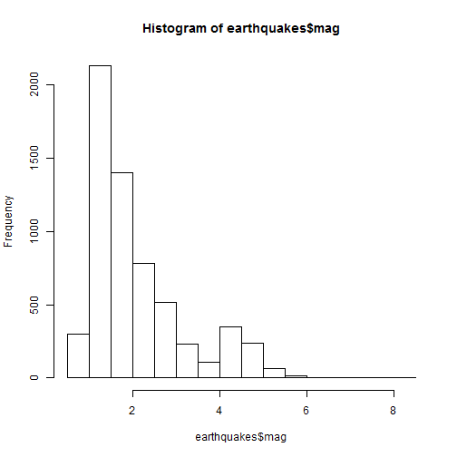

```r
hist(earthquakes$mag)
```